# Importance of Data Viz for Statistics

## From my student projects - 25-26

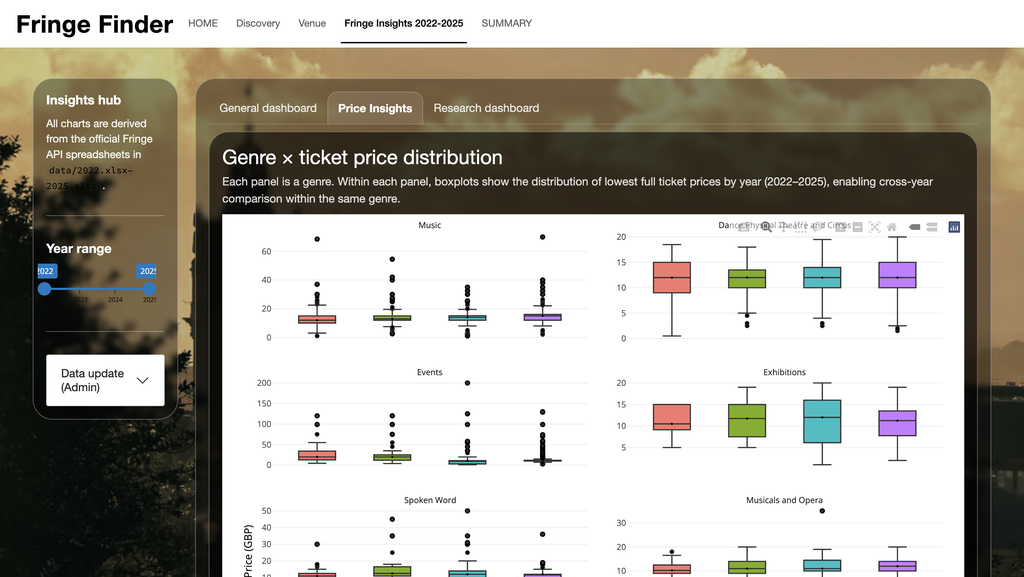

UG project: Visualizing Edinburgh’s Fringe for festivalgoers: Shiny web application study

## From a joint work- Map challenge

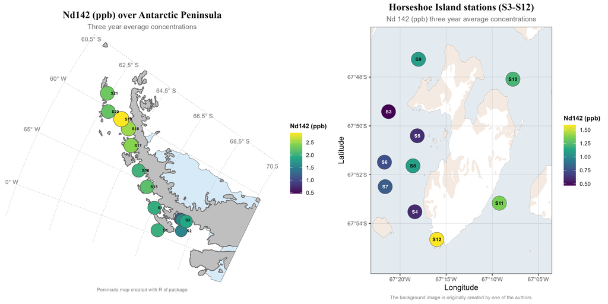

Research paper: Working with small sample data for Antarctic region

## For Teaching

- Shiny based web apps for specific topics
- Targeting visual learners with interactivity, implemented in some courses such as Statistics or Data Science
- One example if time allows!

## ggplot and beyond

## Very promising: Lots of ggplot2 extensions

- [151 registered extensions available](https://github.com/erikgahner/awesome-ggplot2) to explore
- There are created with the same grammer of graphics approach so that they are following similar syntax behind the scene mostly
  - Specific packages for specific tasks can be found such as **patchwork**, **gganimate**, **esquisse**, **ggcorplot** etc.
- Various packages designed for customization and additional theme usage such as **ggthemes**, **ggpubr**
- Some packages are tailored to additional information on top of the visualization such as **ggstatsplot**

## Interactive & Web-Based Visuals

| Package | Interactivity | Typical Tasks | Standout Strengths |
| --- | --- | --- | --- |
| **plotly (R)** | Interactive (HTML) | Dashboards, rich interactive plots | Supports many chart types—including 3D, contour, maps—and works offline |
| **highcharter** | Interactive (JS via R) | Themed charts, interactive dashboards | Leverages Highcharts JS with professional themes (“economist”, “FT”, “538”) |
| **leaflet (R)** | Interactive maps | Web maps with markers, layers | R binding for Leaflet.js; great for interactive maps in Shiny/R Markdown |
| **dygraphs** | Interactive (JS time series) | Time-series charts with brushing | Handles large time-series efficiently, integrates RColorBrewer palettes |

## Additional Tools & Enhancements

- **gganimate** — Add frame-based animations to plots; treat time as an aesthetic. Ideal for dynamic visual storytelling.
- **ggthemes** — Offers extra pre-designed themes and color scales beyond ggplot2 defaults.
- **ggpubr** — Simplifies the creation of publication-ready plots, especially statistical plots like boxplots, histograms, and violin plots.
- **patchwork** — Aids in composing multiple ggplot2 plots into complex layouts easily.
- **RColorBrewer** – Static; provides beautiful sequential/diverging palettes, enhances maps and plots
- **Esquisse** – Interactive GUI; drag‑and‑drop to build ggplot2 charts and extract code
- **GGally** — Extends ggplot2 with tools like ggpairs for easy pairwise plots and correlation matrices.

## Quick Reference: Which to Use When?

- Data transformation pipelines? → tidyverse (especially ggplot2 as the viz endpoint)
- Custom, publication-quality 2D plots? → ggplot2
- Faceted, multivariate plots? → lattice or ggplot2 with suitable faceting and customization
- Browser-based interactive charts? → plotly, leaflet
- 3D interactive graphics, including functions modelled on base graphics → RGL
- Palette design or themes? → ggthemes
- Prefer a GUI to build plots? → Esquisse
- Web app based interactive examples → Shiny

## Some useful resources

## RSS: Best Practices for Data Visualisation

- **[Best Practices for Data Visualisation](https://royal-statistical-society.github.io/datavisguide/)** aims to equip readers with the fundamentals for creating data visualizations that are high-quality, readable, impactful, and accurate in both presentation and interpretation.
- The guide blends both the scientific and creative aspects of visualization — it emphasizes that data viz is not just plotting defaults, but actively telling a story and choosing design elements deliberately to serve that story
- Though primarily aimed at RSS publications (Significance magazine, JRSS Series A, Real World Data Science), the guidance is broadly relevant for any data viz task

*Thanks to Andreas Krause, Nicola Rennie, and Brian Tarran*

## Principles & Choosing Chart Types

To select the right chart type, consider:

1. **Data type** (e.g., numeric, categorical) — tools like *From Data to Viz* use decision trees to suggest suitable chart formats.
2. **Data relationship** (e.g., correlation, ranking, deviation) — platforms like *Visual Vocabulary* guide selection based on the main relationship you want to show

Checklist:

- Be clear on the visualization’s purpose.
- Know your audience.
- Choose chart type based on data structure or relationship.
- Refine with audience’s graph literacy in mind

## Styling & Accessibility

Emphasis is placed on styling for **accessibility**, using thoughtful choices in color, annotation, fonts, and alternative text

- **Unstyled** version uses default colors and labels.
- **Styled** version includes readable font sizes, contrast-aware color fills, in-chart labels, and clear titles/subtitles — vastly improving interpretability

Key styling components:

- Accessible color palettes.
- Effective annotations.
- Legible font sizes and styles.
- Alt text for visual inclusion

## From data to viz

- Where to start might not be easy, so good to explore already published good images
- There are specific visual galleries for both R and Python with code and created images
- In terms of understanding the visual type, when to apply, [From Data to Viz](https://www.data-to-viz.com/)

## Bonus: What about the Python world ?

- In my view (possibly biased but I am happy about it), R seems still more powerful compared to python regarding the available packages/tools
- However, there is a growing list of python libraries with a community also
- In terms of your general programming habits you can start the safest position
- There are nowadays more common packages for both landscape including plotnine as ggplot mirroring in python or applicability of shiny for both

## How about AI impact?

## Data Automation

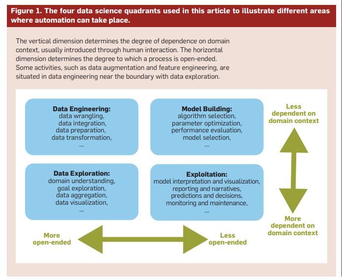

## AI + Data Visualization

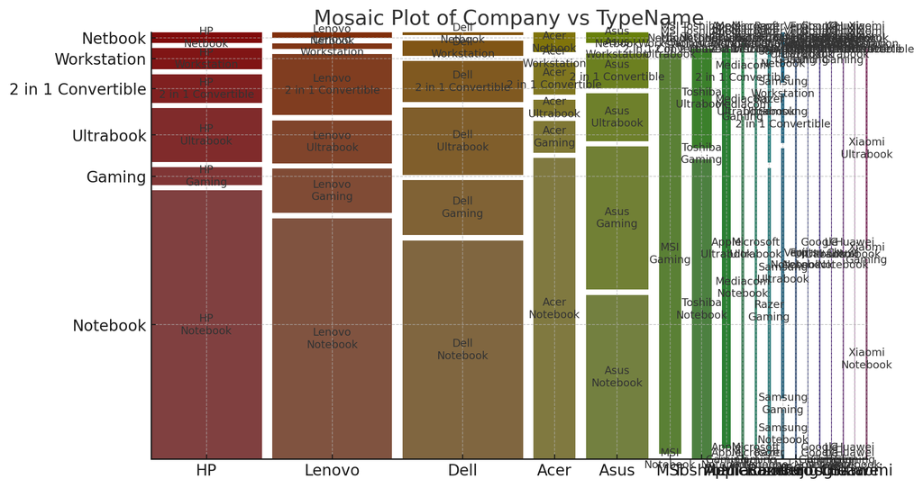

[Decoding AI: The inside story of data analysis in ChatGPT](https://arxiv.org/abs/2404.08480)

[GAIL project report: LLMs are they ready for DS?](https://github.com/oevkaya/GAIL-DS-project/blob/main/Supplementary.pdf)

## LLMs are everyhwhere

- More AI support in R or python nowadays, including specific packages to use LLMs within IDE
- Code generation is being easier - Github Copilot
- Specific package AI helper, such as Shiny Assistant or others

## How to train ourselves?

- More AI empowered data viz coming (creating by speaking), but the design and interpretation should require active human-being involvements
- Easier to create web-based platforms like shiny and its flexibilities allow users to interact with data more, when it is really useful
- To explore/reproduce and examine different data viz examples via open sources, critique them is the key for expanding our knowledge
- Following specific up-to-date websites or pioneering people in the field such as [Cara Thompson](https://www.cararthompson.com/), [Nicola Rennie](https://nrennie.rbind.io/)
- Exercising and working together via specific platforms, R-based community events, or data viz competitions or datathons are good sources of learning opportunities

## Good bad and Ugly

[figure not shown]

## Some readings you might enjoy

- [Data Visualization The Good, the Bad, the Weird, Nam Wook Kim](https://www.namwkim.org/datavis/slides/2.%20Data%20Visualization-%20The%20Good,%20the%20Bad,%20the%20Weird.pdf)
- [Data visualization in AI-assisted decision-making: a systematic review](https://www.frontiersin.org/journals/communication/articles/10.3389/fcomm.2025.1605655/full)
- [From Data to Viz](https://www.data-to-viz.com/)
- [The Art of Data Visualization with ggplot2 The TidyTuesday Cookbook](https://nrennie.rbind.io/art-of-viz/)
- [Fundamentals of Data Visualization](https://clauswilke.com/dataviz/proportional-ink.html)
- [Dataviz Inspiration](https://www.dataviz-inspiration.com/)